# Proyecto Final

Luis Domínguez, Miguel Gutiérrez, Cassandra López, Cristina Escobar

2024-04-22

# Proyecto Final

## Primera Parte: Selección del Tema y Análisis Exploratorio de los Datos

### 1. Selección del Tema

Selecciona un tema de tu interés al que se pueda aplicar un modelo ARIMA para una serie de tiempo.

**Predicción de precios de acciones de BMW**

### 2. Justificación del Tema

Justifica brevemente la relevancia del tema y la herramienta que utilizarás (modelo ARIMA para una serie de tiempo). Busca antecedentes en la literatura especializada.

**Utilizaremos los datos históricos del precio de las acciones de BMW y el modelo ARIMA para predecir el comportamiento futuro de sus precios de acciones.**

### 3. Recopilación de Datos

Recaba los datos que necesites y determina la ventana de tiempo que sea más adecuada para tu investigación.

```r
Xt<-read.csv("DatosBMW.csv")
Xt_cierre <- select(Xt, Cierre)
# Xt_cierre<-as.ts(Xt_cierre)
# plot(Xt_cierre, main="Precio de las acciones de BMW", ylab="Precio", xlab="Tiempo")
```

### 4. Descripción de la Variable

Describe la variable que utilizarás, los nombres que utilizarás, las unidades, la fuente de dónde obtuviste los datos.

**Variable a utilizar: cierre del precio diario del acción**

**Unidades: Euros**

**Fuente: https://mx.investing.com/equities/bay-mot-werke-historical-data**

### 5. Organización de Datos en RStudio

Organiza los datos en una tabla para RStudio. Coloca los nombres adecuados en las columnas usando la biblioteca `dplyr()`.

```r
Xt_cierre<-ts(Xt_cierre, start=c(2009,99), end=c(2024,113), frequency=365)
Xt_cierre
```

```
## Time Series:
## Start = c(2009, 99)
## End = c(2024, 113)
## Frequency = 365
##    [1] 105.850 105.850 106.950 105.950 106.450 109.700 109.500 111.900 111.500
##   [10] 113.850 114.750 112.500 114.700 111.850 106.650 106.960 106.160 106.560
##   [19] 106.240 104.120 104.800 106.360 107.120 105.980 105.680 105.200 108.500
##   [28] 109.780 106.880 107.140 106.960 107.700 109.360 109.940 109.800 109.220
##   [37] 109.160 107.680 107.480 106.720 105.080 104.300 101.820 102.820 104.100
##   [46] 102.620 101.160 100.880 102.140 102.000 101.960  99.140  97.560  96.570
##   [55]  97.980  97.030  96.780  95.000  94.910  94.770  93.690  93.550  93.560
##   [64]  93.310  92.300  93.060  92.780  95.760  95.520  96.850  98.460  99.900
##   [73] 100.820 101.200 100.660 101.000  99.510 101.780 100.780 100.440 100.400
##   [82] 100.640  99.550 100.420 100.880 101.020 103.060 102.540  99.690 100.940
##   [91] 101.300 100.920  98.600  99.350  97.660  96.160  96.190  95.590  96.070
```

[output cut: 599 more lines]

### 6. Gráfica de la Serie de Tiempo

Elabora una gráfica de tu serie de tiempo. Cada gráfica debe de ir acompañada de una breve explicación o descripción. Cada afirmación debe de ir acompañada de una breve justificación. Además, debe de ir con los nombres adecuados en los ejes Y y X. Usa las funciones `xlab` y `ylab` de la función `plot()`.

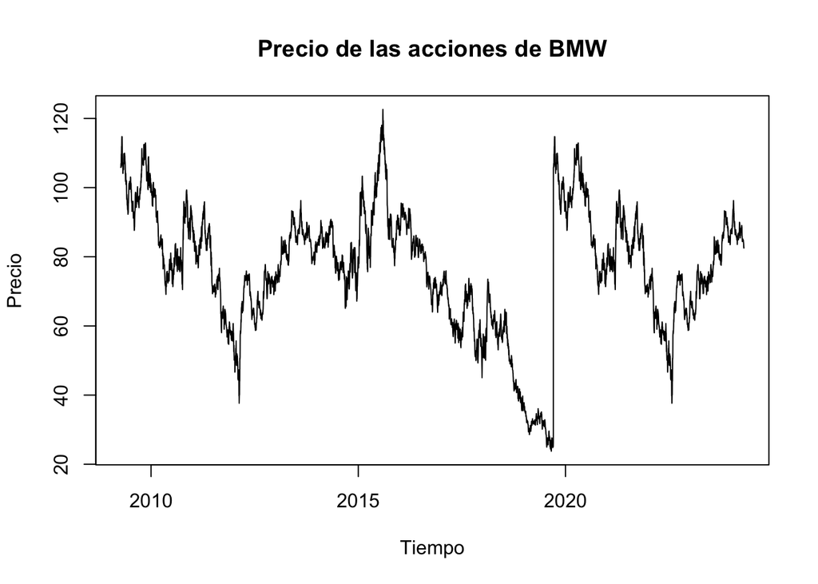

```r
plot(Xt_cierre, main="Precio de las acciones de BMW", ylab="Precio", xlab="Tiempo")
```

La gráfica nos muestra el precio de las acciones en euros de la empresa BMW desde el 2009 hasta el 22 de abril del 2024.

### 7. Prueba de Estacionariedad

Determina si tu serie de tiempo es estacionaria o no. Utiliza la prueba de Dickey Fuller Aumentada. Determina si es integrada y de qué orden.

```r
adf.test(Xt_cierre, alternative = "stationary")
```

```
##
##  Augmented Dickey-Fuller Test
##
## data:  Xt_cierre
## Dickey-Fuller = -3.6618, Lag order = 17, p-value = 0.02666
## alternative hypothesis: stationary
```

### 8. Función de Autocorrelación (ACF)

Grafica la ACF de tu serie de tiempo. Escribe los estimadores de la ACF de tu serie de tiempo.

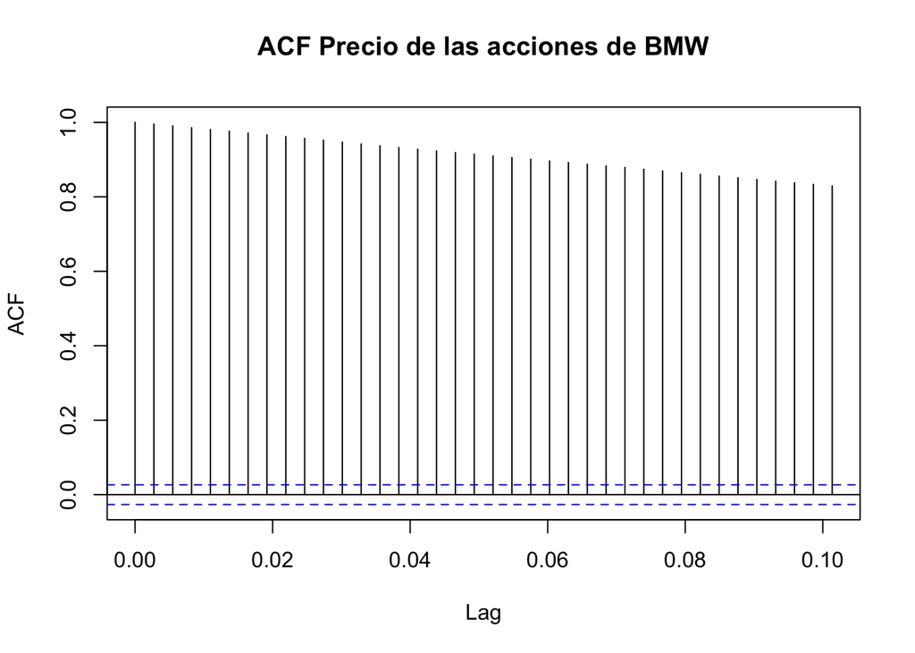

```r
acfx<-acf(Xt_cierre, main="ACF Precio de las acciones de BMW")
```

```r
acfx
```

```
##
## Autocorrelations of series 'Xt_cierre', by lag
##
## 0.00000 0.00274 0.00548 0.00822 0.01096 0.01370 0.01644 0.01918 0.02192 0.02466
##   1.000   0.995   0.991   0.986   0.981   0.976   0.972   0.967   0.962   0.957
## 0.02740 0.03014 0.03288 0.03562 0.03836 0.04110 0.04384 0.04658 0.04932 0.05205
##   0.952   0.947   0.942   0.937   0.932   0.928   0.924   0.919   0.914   0.910
## 0.05479 0.05753 0.06027 0.06301 0.06575 0.06849 0.07123 0.07397 0.07671 0.07945
##   0.906   0.901   0.897   0.892   0.888   0.883   0.879   0.874   0.869   0.865
## 0.08219 0.08493 0.08767 0.09041 0.09315 0.09589 0.09863 0.10137
##   0.860   0.856   0.851   0.847   0.842   0.838   0.834   0.829
```

### 9. Función de Autocorrelación Parcial (PACF)

Grafica la PACF de tu serie de tiempo. Escribe los estimadores de la PACF de tu serie de tiempo.

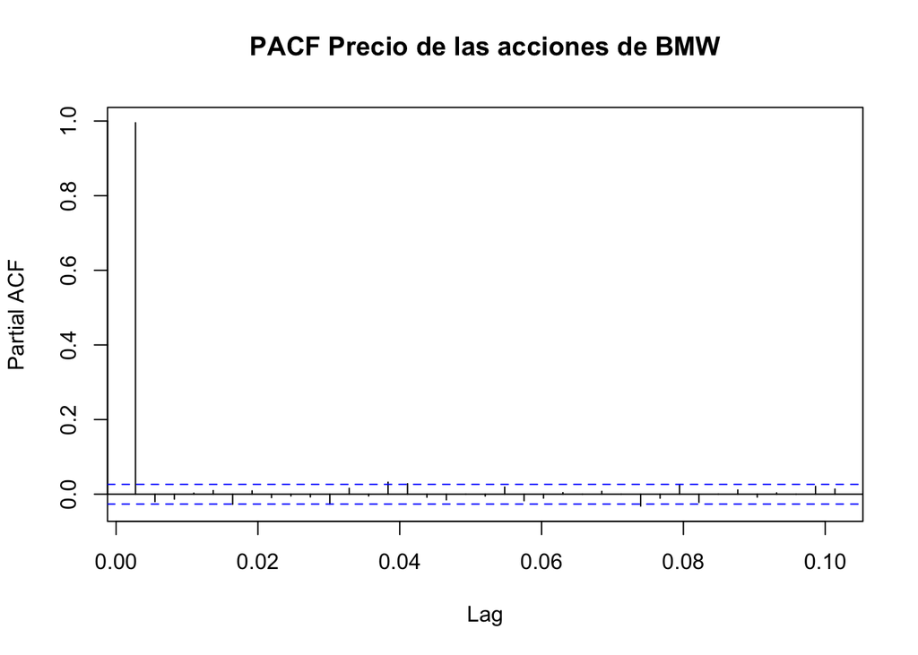

```r
pacfx<-pacf(Xt_cierre, main="PACF Precio de las acciones de BMW")
```

```r
pacfx
```

```
##
## Partial autocorrelations of series 'Xt_cierre', by lag
##
## 0.00274 0.00548 0.00822 0.01096 0.01370 0.01644 0.01918 0.02192 0.02466 0.02740
##   0.995  -0.020  -0.013   0.003   0.010  -0.027   0.009  -0.009  -0.005  -0.007
## 0.03014 0.03288 0.03562 0.03836 0.04110 0.04384 0.04658 0.04932 0.05205 0.05479
##  -0.027   0.016  -0.005   0.032   0.028  -0.008  -0.015   0.000  -0.005   0.019
## 0.05753 0.06027 0.06301 0.06575 0.06849 0.07123 0.07397 0.07671 0.07945 0.08219
##  -0.017  -0.010   0.004   0.000   0.008   0.000  -0.032  -0.011   0.026  -0.022
## 0.08493 0.08767 0.09041 0.09315 0.09589 0.09863 0.10137
##   0.000   0.011  -0.008   0.004   0.000   0.021   0.014
```

## Segunda parte.

### Ajuste del modelo.

#### (1) Mejor modelo AIC

**(a)** Ajusta un modelo ARIMA a tu serie de tiempo. En esta ocasión utilizaremos el criterio de información de Akaike para seleccionar el mejor modelo. Usa el método visto en clase. Imprime una tabla con los 5 mejores modelos, según AIC.

```r
P<-2
D<-1
Q<-5
tabla<-data.frame()
for(p in 0:P){
  for(d in 0:D){
    for(q in 0:Q){
      modelo<-arima(Xt_cierre,order=c(p,d,q))
      AIC<-AIC(modelo)
      sbic<-AIC(modelo,k=log(length(Xt_cierre)))
      tabla<-rbind(tabla,c(p,d,q,AIC,sbic))
    }
  }
}
tabla<-rename(tabla, 'p'=1,'d'=2,'q'=3,'AIC'=4,'sbic'=5)
tabla<-tabla[order(tabla$AIC),]
tabla <- head(tabla, 5)
tabla
```

```
##    p d q      AIC     sbic
## 34 2 1 3 21327.20 21366.86
## 7  0 1 0 21331.58 21338.19
## 19 1 1 0 21331.66 21344.88
## 8  0 1 1 21331.69 21344.92
## 25 2 0 0 21332.36 21358.80
```

**(b)** Determina si cada uno de los coeficientes del mejor modelo según AIC es significativo, incluyendo el intercepto. En caso de que un coeficiente no sea significativo pasa al siguiente mejor modelo.

```r
ajuste1<-arima(Xt_cierre,order=c(0,1,0))
ajuste1
```

```
##
## Call:
## arima(x = Xt_cierre, order = c(0, 1, 0))
##
##
## sigma^2 estimated as 2.852:  log likelihood = -10664.79,  aic = 21331.58
```

```r
confint(ajuste1)
```

```
##      2.5 % 97.5 %
```

El modelo (0,1,0) representa una caminata aleatoria

**(c)** Calcula los intervalos de confianza de los estimadores del mejor modelo.

Como es una caminata aleatoria, no hay intervalos de confianza.

**(e)** Calcula los intervalos de confianza para los parámetros que calculaste.

```r
confint(ajuste1)
```

```
##      2.5 % 97.5 %
```

#### (2) Mejor modelo de ajuste de R.

**(a)** Usa la función de R `auto.arima(X)` donde $X$ es la serie de tiempo. Para que R ajuste un modelo ARIMA de manera automática.

```r
mejor_modelo<-auto.arima(Xt_cierre)
mejor_modelo
```

```
## Series: Xt_cierre
## ARIMA(0,1,0)
##
## sigma^2 = 2.852:  log likelihood = -10664.79
## AIC=21331.58   AICc=21331.58   BIC=21338.19
```

**(b)** Determina si cada uno de los coeficientes del modelo escogido es significativo, incluyendo el intercepto. En caso de que un coeficiente no sea significativo pasa al siguiente mejor modelo.

Debido a que nuestro modelo es una caminata aleatoria, no hay coeficientes significativos.

**(c)** Escribe la ecuación de tu modelo.

$Xt = X_{t-1} + W_t$

**(d)** Calcula los intervalos de confianza para los parámetros que calculaste.

```r
confint(mejor_modelo)
```

```
##      2.5 % 97.5 %
```

## Tercera parte

#### 1. Grafica los residuos de tu modelo. Grafica la acf de los residuos de tu modelo. Interpreta ambas gráficas.

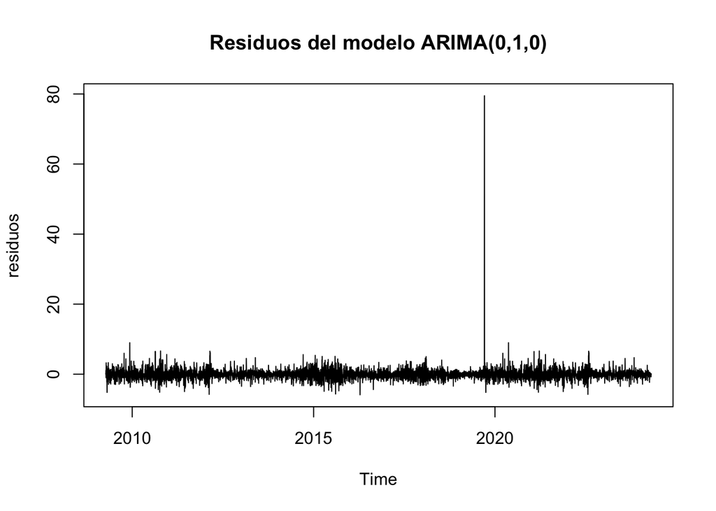

```r
residuos<-resid(mejor_modelo)
plot(residuos, main="Residuos del modelo ARIMA(0,1,0)")
```

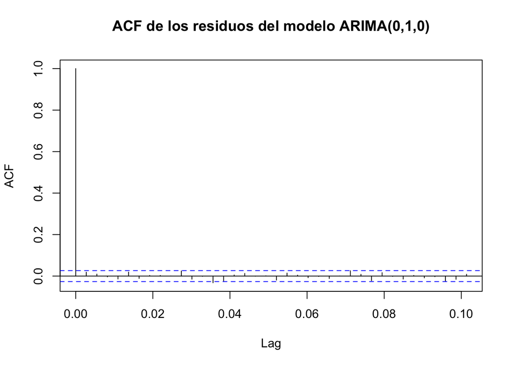

```r
acf(residuos, main="ACF de los residuos del modelo ARIMA(0,1,0)")
```

La primera gráfica tiene una oscilación constante, hasta poco antes del 2020, que fue cuando se disparó el precio de las acciones de BMW.

En cuanto a la segunda, al ser una caminata aleatoria, no van a haber residuos significativos.

#### 2. Usa la prueba de Ljung-Box para revisar si los residuos de tu modelo son ruido blanco. Interpreta el resultado.

```r
Box.test(residuos, lag=20, type="Ljung-Box")
```

```
##
##  Box-Ljung test
##
## data:  residuos
## X-squared = 24.178, df = 20, p-value = 0.2347
```

#### 3. Realiza un histograma de los residuos de tu modelo. Con la función `hist(resid(modeloX),freq=FALSE)` donde `modeloX` es el nombre de la variable del ajuste de tu modelo.

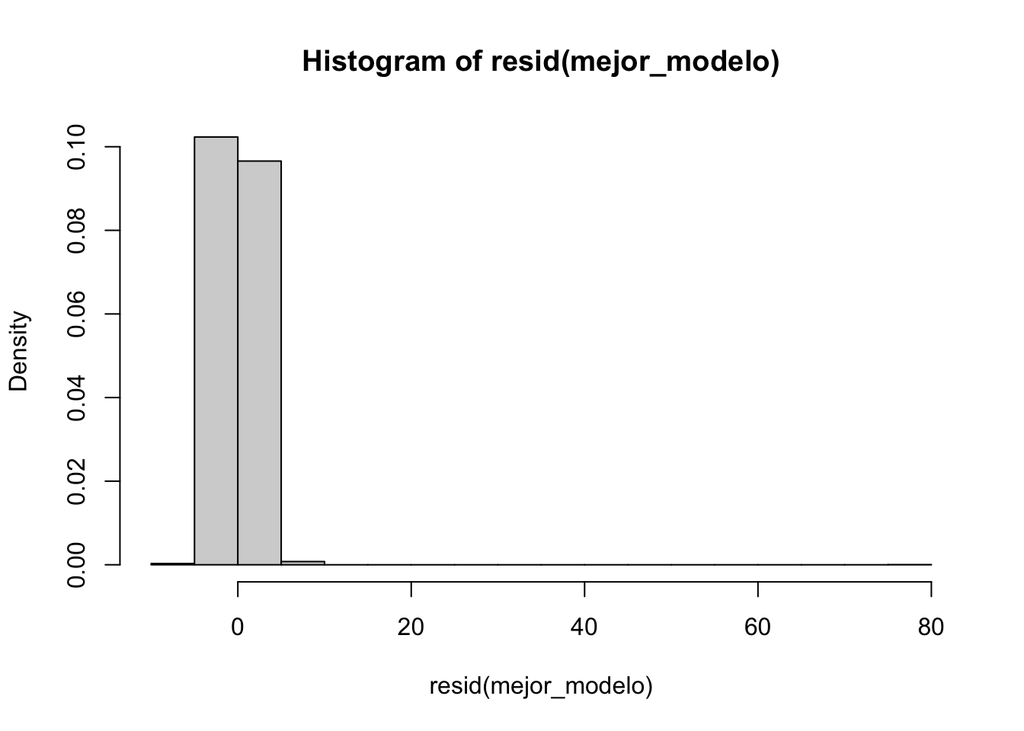

```r
hist(resid(mejor_modelo),freq=FALSE)
```

#### 4. Revisa que tus residuos tengan una distribución normal:

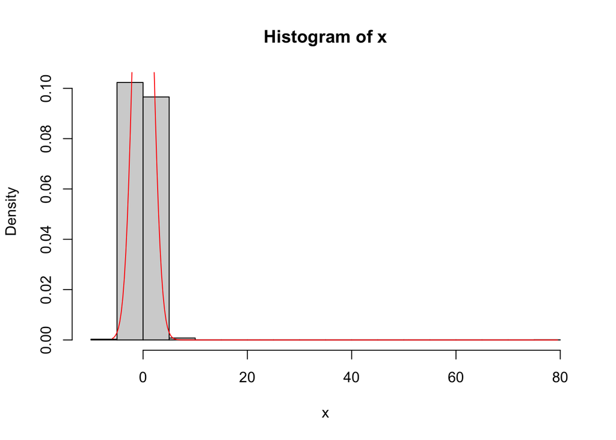

```r
# guarda los residuos en una variable, por ejemplo, x
x <- resid(mejor_modelo)
# crea un intervalo del mínimo residuo al máximo residuo
intervalo <- seq(min(x), max(x), length = 300)
# crea una distribución normal en el intervalo, con la media y desv. est. de los residuos
distnormal <- dnorm(intervalo, mean=mean(x),sd=sd(x))
# grafica el histograma de los residuos
hist(x,freq=FALSE)
# grafica la distribución normal encima del histograma
lines(intervalo,distnormal, col='red')
```

#### 5. Realiza un pronóstico usando tu modelo con la función `forecast()` y grafica el pronóstico. Para esto necesitas la biblioteca `forecast` (`library(forecast)`).

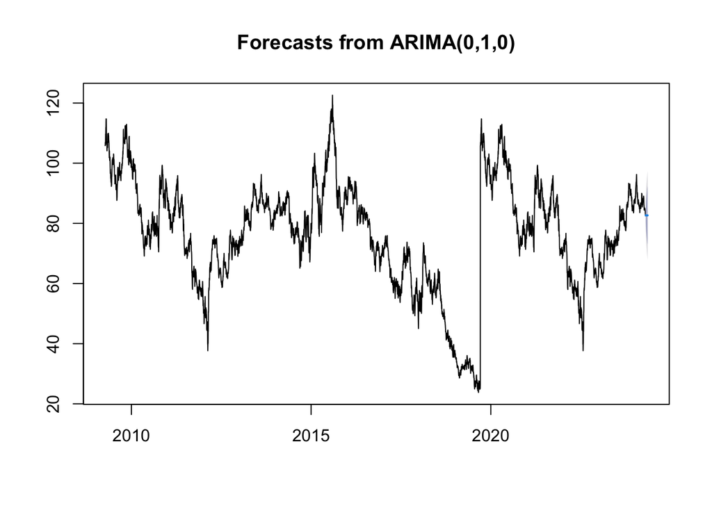

```r
pronostico <- forecast(mejor_modelo, h = 20)
plot(pronostico)
```

#### 6. Calcula las raíces de tu modelo con la función `autoplot()`.

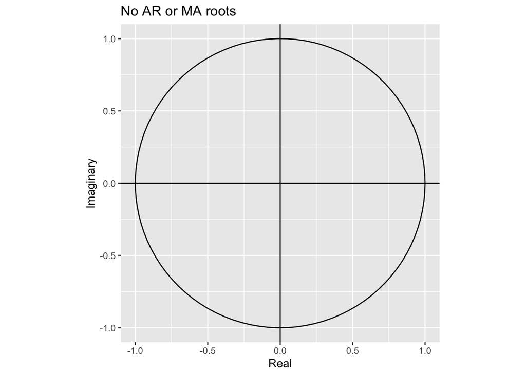

```
Si las raíces están fuera (o muy cerca) del círculo unitario, tu modelo será numéricamente inestable y no será adecuado para hacer un pronóstico.
```

```r
autoplot(mejor_modelo)
```

#### 7. Da una interpretación de cada uno de los coeficientes numéricos que estimaste en la primera parte.

Al ser una caminata aleratoria, no hay coeficientes significativos.

#### 8. Redacta un breve resumen de lo que encontraste, evita ser repetitivo. Así mismo, comenta sobre la relación entre los datos y los parámetros del modelo. Discute también las áreas de oportunidad de tu estudio, ya sea debido a la recolección de datos o a la metodología. Escribe algunas sugerencias para futuros trabajos. Incluye la bibliografía que hayas utilizado.

Fuente: https://mx.investing.com/equities/bay-mot-werke-historical-data